# Chapter 10: Recap

Guido Biele

11.05.2022

# Generalized linear models

So far we have used linear regressions, where we modeled the outcome as follows:

$$y \sim Normal(\mu,sigma) \\
\mu = \alpha + \beta X$$

This regression works generally well, even if $\small y$ is not normally distributed. (The residuals should be though. And a posterior predictive plot is always useful!)

## Distributions

However, for some outcome types a linear regression simply does not work. This is particularity clear when the outcome is bound to be equal to or larger than zero (like counts that “clump” at zero) or when the outcome is binary.

As an example the next figure shows end of year math grades in a Portuguese school.[^1]

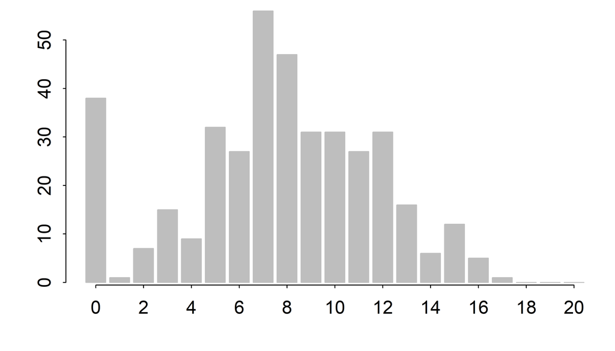

```r
df=read.table("data/student-mat.csv",sep=";",header=TRUE)
df = df[df$Medu>0,]
set_par()
x = barplot(c(table(df$G3),0,0,0), xaxt = "n", border = "grey")
axis(1,at = x[seq(0,20,2)+1], labels = seq(0,20,2))
```

In these situations we can use this kind of model:

$$y \sim dist(\theta_1,\theta_2) \\$$

Here $\small dist(\theta_1,\theta_2)$ is a distribution with two parameters[^2] that is consistent with the observed data.

**Choosing a different distribution means choosing a different likelihood function**. That is, we exchange `dnomr` with an alternative distribution that is appropriate for the data.

Here are a few examples:

- The [Binomial distribution](https://en.wikipedia.org/wiki/Binomial_distribution) models the *“number of successes in a sequence of n independent experiments, each asking a yes–no question”*. Hence we use the Binomial distribution function to calculate the likelihood of the data given model and parameters when we model number of successes. A special case is when we have only one trial / experiment, the Binomial distribution models binary outcomes.

[figure not shown]

```r
set_par()
x = seq(0,5,1)
plot(x-.2,dbinom(x, 5, .2),"h", xlim = c(0,20), lwd = 2,
     ylab = "probability mass", xlab = "number of success")
x = seq(0,10,1)
lines(x,dbinom(x, 10, .5),"h", col = "blue", lwd = 2)
x = seq(0,20,1)
lines(x+.2,dbinom(x, 20, .75),"h", col = "red", lwd = 2)
legend("topright",
       lwd = 2, col = c("black","blue","red"),
       legend = c(
         expression(theta[1]~" = n = 5, "~theta[2]~" = p = .2"),
         expression(theta[1]~" = n = 10, "~theta[2]~" = p = .5"),
         expression(theta[1]~" = n = 30, "~theta[2]~" = p = .75")
       ),
       bty = "n")
```

- The [Poisson distribution](https://en.wikipedia.org/wiki/Poisson_distribution) *“expresses the probability of a given number of events occurring in a fixed interval of time or space if these events occur with a known constant mean rate”* . Hence we use the Poisson distribution function to calculate the likelihood of the data given model and parameters when we occurrence of events (counts).

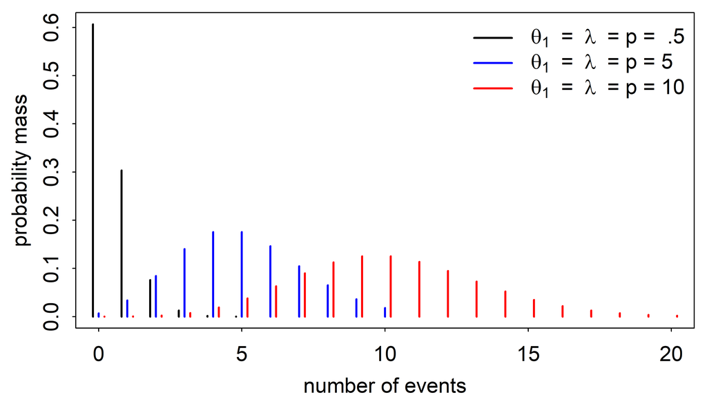

```r
set_par()
x = seq(0,5,1)
plot(x-.2,dpois(x, .5),"h", xlim = c(0,20), lwd = 2,
     ylab = "probability mass", xlab = "number of events")
x = seq(0,10,1)
lines(x,dpois(x, 5),"h", col = "blue", lwd = 2)
x = seq(0,20,1)
lines(x+.2,dpois(x, 10),"h", col = "red", lwd = 2)
legend("topright",
       lwd = 2, col = c("black","blue","red"),
       legend = c(
         expression(theta[1]~" = "~lambda~" = p =  .5"),
         expression(theta[1]~" = "~lambda~" = p = 5"),
         expression(theta[1]~" = "~lambda~" = p = 10")
       ),
       bty = "n")
```

## Link functions

As can be seen from the previous plots, the expected value (the mean parameter) of the Binomial and Poisson distributions are constrained:

- For the Binomial distribution: $\small 0 \leq \textrm{success probability } p \leq 1$
- For the Poisson distribution: $\small 0 \leq \textrm{expected rate } \lambda$.

But if we would just model e.g.
$$p = \alpha + \beta X$$
we could get values between minus and plus infinity. Therefore the generalized linear model also used link functions that map the result of the *linear predictor* $\small \alpha + \beta X$ to the desired range:

$$p = link(\alpha + \beta X)$$

GLMs use different link functions for different distributions to implement different constraints:

- Link function for the Binomial distribution: $\small p = inv.logit(\alpha + \beta X)$

$$\small inv.logit(x) = \frac{1}{1+exp(-x)} = \frac{exp(x)}{1+exp(x)}$$

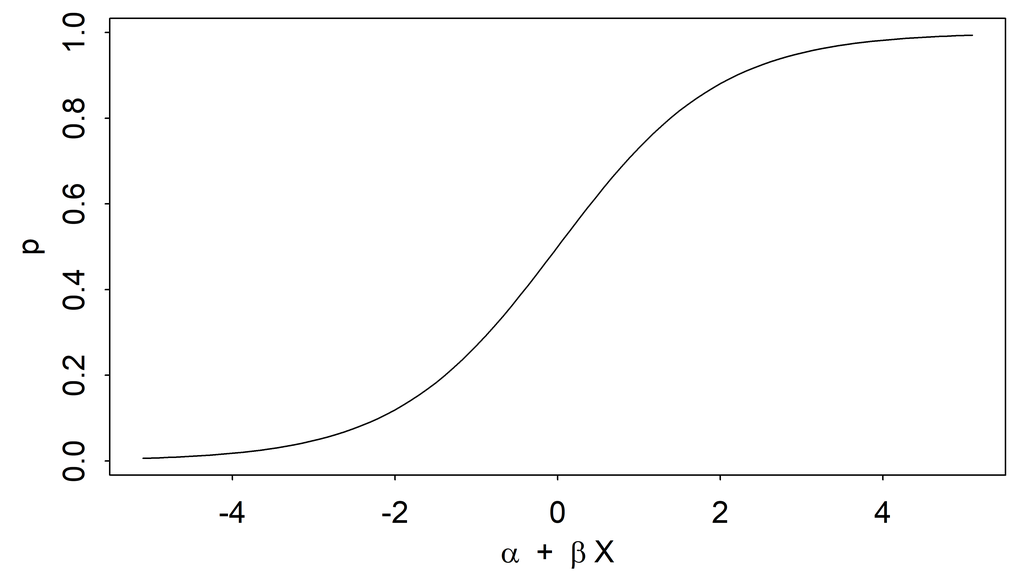

```r
set_par()
curve(boot::inv.logit(x),-5.1,5.1,n = 100,
      xlab = expression(alpha~" + "~beta~"X"), ylab = "p")
```

- For the Poisson: $\lambda = exp(\alpha + \beta X)$

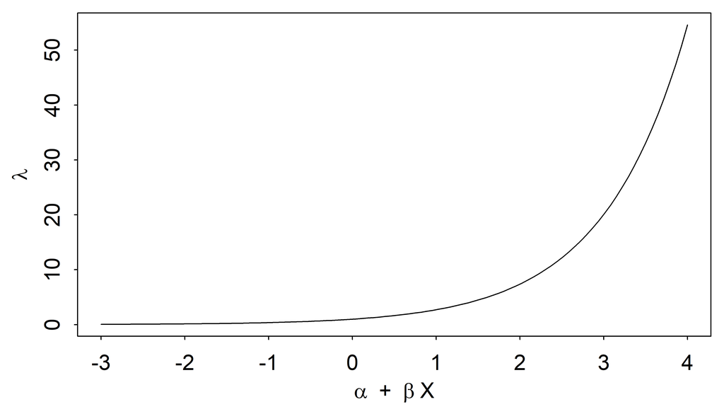

```r
set_par()
curve(exp(x),-3,4,n = 100,
      xlab = expression(alpha~" + "~beta~"X"), ylab = expression(lambda))
```

One important effect of link functions is that we cannot interpret regression weights in the same way as for simple linear regression. In a nutshell, if link functions exponentiate the linear predictor, regression weights represent multiplicative rather than additive effects.

In `R`, `family` is the term for an object that tells a regression model both what outcome distribution to use and what link function to use.

When do we use the Binomial and when the Poisson Likelihood?

- Poisson when there is no clear limit to the number of counts
  - number of apples in an orchard
  - number of people with a PhD
  - number of romantic partners per person
- Binomial when the counted number of success is limited by the number of trials. This is the reason that the Binomial distribution has 2 parameters.
  - number of people with a PhD that have red hair
  - number of Norwegian romantic partners per person

# Logistic regression

For a hands on example for logistic regression we will try to predict failing the math class with the Portugese school data shown above. In particular, we will use these predictors:

- maternal education
- numbers of times the class was failed previously

It is always a good idea to plot the data first:

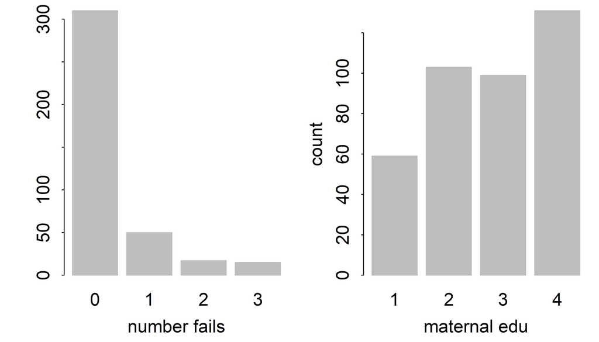

```r
data.list = list(
  Medu = df$Medu,
  failures = df$failures,
  fail = df$G3 == 0
)
set_par(mfrow = c(1,2))
table(data.list$failures) %>% barplot(border = "grey",   xlab = "number fails")
table(data.list$Medu) %>% barplot(border = "grey", ylab = "count", xlab = "maternal edu")
```

We are centering `Medu`, so that the intercept measures odds of “middle high” maternal education.

```r
data.list$cMedu = data.list$Medu-2.5
```

We begin the analysis with an intercept model only. Especially if one is not familiar with a model, it is good to start simple and add complexity step by step.

```r
model = alist(
  fail ~ dbinom(1,p),
  logit(p) <- a,
  a ~ dnorm(0,10)
)
```

## Prior predictive check

And we estimate the model with `ulam` (i.e. Stan):

```r
u.fit_I = ulam(
  model,
  data = data.list,
  iter = 2000,      # 2000 iterations, (1000 warmup)
  chains = 4,       # four chains, to check convergence
  cores = 4,        # use 4 cores in parallel
  cmdstan = TRUE)   # use cmdstanr not rstan
```

We extract the prior and plot the prior prediction for the failure rate:

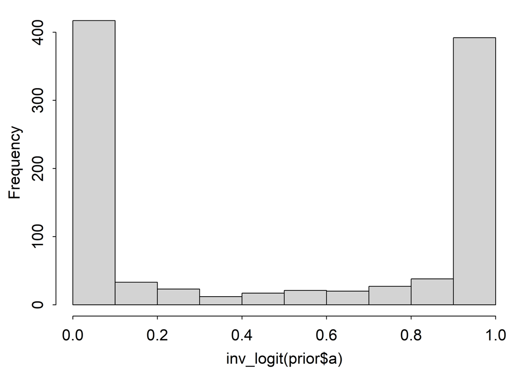

```r
prior = extract.prior(u.fit_I)
set_par()
hist(inv_logit(prior$a), main="")
```

To see what is going on here, lets overlay the logistic function on the prior:

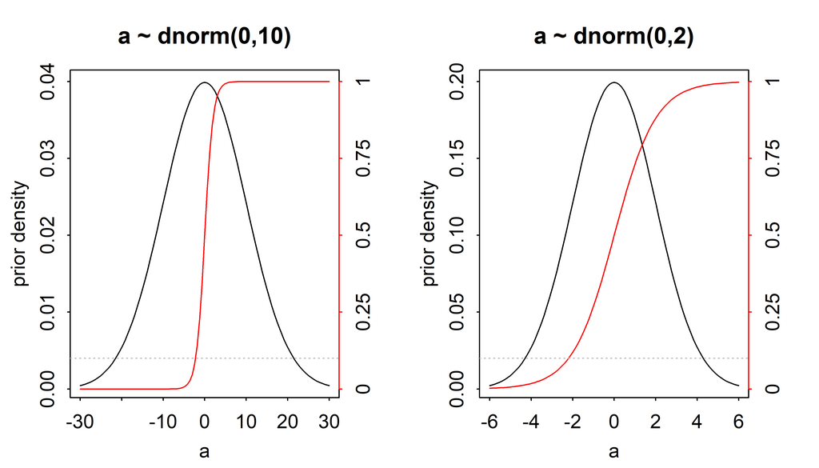

```r
set_par(mfrow = c(1,2), mar=c(3,3,3,3), cex = 1)

curve(dnorm(x,0,10),-30,30, ylab = "prior density", xlab = "a")
axis(4,at = seq(0,0.04, length.out = 5),
     labels = seq(0,1,length.out = 5), col = "red")
curve(inv_logit(x)/25, add = T, col = "red")
abline(h = .1/25, lty = 3, col = "grey")
title("a ~ dnorm(0,10)")

curve(dnorm(x,0,2),-6,6, ylab = "prior density", xlab = "a")
axis(4,at = seq(0,0.2, length.out = 5),
     labels = seq(0,1,length.out = 5), col = "red")
curve(inv_logit(x)/5, add = T, col = "red")
abline(h = .1/5, lty = 3, col = "grey")
title("a ~ dnorm(0,2)")
```

With a wide prior, most of the probability mass is either smaller than -5, leading to p very close to 0, or larger than 5, leading to p close to 1. Hence we will use a tighter prior on a.

How about the regression coefficients $\small beta$? Regression coefficients are log odds ratios.

For instance, lets assume the following:

- for children who never failed a class, 2 out of 100 children fail the class now
- for children who once failed a class, 4 out of 100 children fail the class

then the odds ratio is :

$$\begin{align*}
OR = & \frac{\textrm{failure odds with no prior fail}}{\textrm{failure odds with prior fail}} \\
= & \frac{\frac{2}{98}}{\frac{4}{96}} = \frac{.0204}{.0417} = .49
\end{align*}$$

> Note that this specific odds ratio comes close to the risk ratio of $\small .2 / .4 = .5$. This is, however, not generally the case. If the probabilities are far away from zero, risk ratio and odds ratio do not align! We can see this if we just multiply the probability of failure by 15 in both groups:
> $$\begin{align*}
> OR = \frac{\frac{30}{70}}{\frac{60}{40}} = \frac{.428}{.667} = .29
> \end{align*}$$

Lets get back to specifying our prior for $\small \beta$:

- We had an odds ration of 0.49, which corresponds to a log odds ratio of log(.49) ~ -.7.
- This means that if we assume that probability is low and a shift from no to one prior fail comes with a doubling of the fail probability, we should comfortably allow $\small \beta$ values of size .7.
- If we wanted to set an informative shrinkage prior, which however does not prefer one direction of the effect, we could set a `dnorm(0,.7)` prior.
- But we are not so sure and don’t like to informative priors, so we set a `dnorm(0,2)` prior.

```r
model = alist(
  fail ~ dbinom(1,p),
  logit(p) <- a + b1*failures,
  a ~ dnorm(0,2),
  b1 ~ dnorm(0,2)
)
u.fit_F = ulam(
  model,
  data = data.list,
  iter = 2000,      # 2000 iterations, (1000 warmup)
  chains = 4,       # four chains, to check convergence
  cores = 4,        # use 4 cores in parallel
  cmdstan = TRUE)   # use cmdstanr not rstan

prior = extract.prior(u.fit_F)
```

Now we can use the `link_ulam` function and new data to generate predictions from the prior.

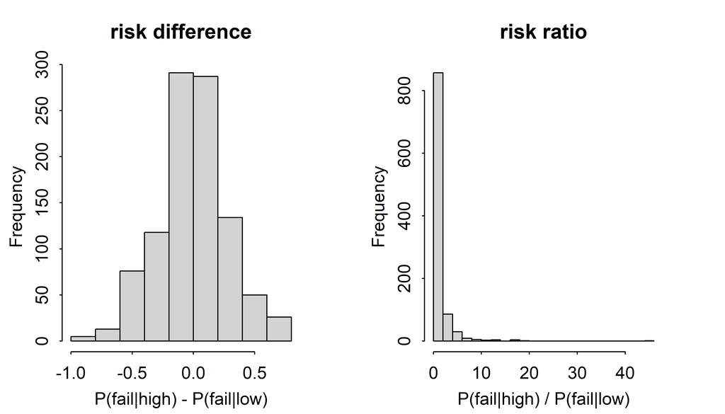

```r
p = link_ulam(
  u.fit_F, post = prior,
  data = list(failures = c(0,1)))
set_par(mfrow = c(1,2), mar=c(3,3,3,3), cex = 1)
hist(p[,2]-p[,1],
     main = "risk difference", xlab = "P(fail|high) - P(fail|low)")
hist(p[,2]/p[,1], breaks = 30,
     main = "risk ratio", xlab = "P(fail|high) / P(fail|low)")
```

These differences and ratios are pretty large, so it is safe to make the prior a bit narrower and set the standard deviation for the regression weights to 1.

Here is the our model so far, which include previous class fails and maternal education as predictors:

```r
model = alist(
  fail ~ dbinom(1,p),
  logit(p) <- a + b1*failures + b2*cMedu,
  a ~ dnorm(0,2),
  b1 ~ dnorm(0,1),
  b2 ~ dnorm(0,1)
)
u.fit_FE = ulam(
  model,
  data = data.list,
  log_lik = TRUE,   # for model comparison
  iter = 2000,      # 2000 iterations, (1000 warmup)
  chains = 4,       # four chains, to check convergence
  cores = 4,        # use 4 cores in parallel
  cmdstan = TRUE)   # use cmdstanr not rstan
```

Some quick convergence diagnostics:

```r
precis(u.fit_FE, depth = 2)
```

```
##          mean        sd       5.5%       94.5%    n_eff     Rhat4
## a  -2.5783076 0.2182074 -2.9393522 -2.24684285 2403.704 0.9998309
## b1  0.6857156 0.1760878  0.4006280  0.96134102 2374.190 1.0008734
## b2 -0.3055052 0.1693658 -0.5826485 -0.03904426 2735.873 1.0006003
```

Which predictions one generates from the prior depends on research questions and domain knowlegde. My approach is to check if prior-predicted data are broadly consistent with the overall distribution of the data and to check if effect estimnates fall into a plausible range. The latter is easier for gaussian models and harder for models with exponential link functions. One simple rule of thumb for logistic or binomial regressions is that with a $\small Normal(0,1)$ prior on regression coefficients the the 97.5 percentile is 1.96. If we exponentiate this we get 7, wich means that a $\small Normal(0,1)$ prior expresses the pior information that the OR is probably not much larger then 7. Note that this prior would still be overwhelmed if we have a reasonable amount (N>25)[^3] of data.

## Posterior predictive checks

To see if our model describes the data well, we plot model predicted and observed data together:

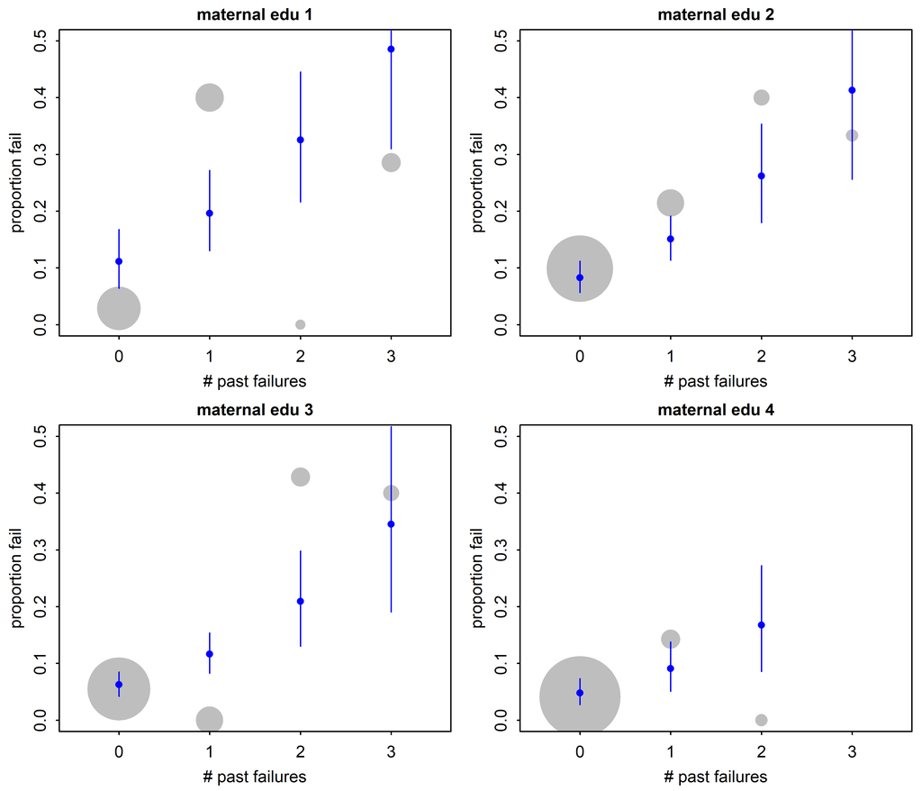

```r
aggr.fun = function(x) return(c(mean = mean(x), N = length(x)))
obs =
  aggregate(
  data.list$fail,
  by = with(data.list,
            data.frame(cMedu = cMedu, Medu = Medu, failures = failures)),
  aggr.fun
  )
obs = cbind(obs,obs$x)

sim.data =
  unique(as.data.frame(data.list)[,c(2,4)])

p = link_ulam(
  u.fit_FE,
  data = sim.data)

pp.stats = cbind(
  sim.data,
  m = colMeans(p),
  t(apply(p,2,PI))
)

set_par(mfrow = c(2,2), mar=c(3,3,1.5,0.5), cex = .75)
tmp =
  lapply(unique(obs$cMedu), function(x) {
  plot(obs[obs$cMedu == x,"failures"],
       obs[obs$cMedu == x,"mean"],
       cex = sqrt(obs[obs$cMedu == x,"N"]),
       xlim = c(-.5,3.5), ylim = c(0,.5),
       ylab = "proportion fail",
       xlab = "# past failures",
       xaxt = "n", pch = 16, col = "grey")
    title(paste("maternal edu",x+2.5),line = 0.5, cex.main = 1)
    axis(1,at = 0:3)
    points(pp.stats[pp.stats$cMedu == x,"failures"],
       pp.stats[pp.stats$cMedu == x,"m"], pch = 16, col = "blue")
    arrows(pp.stats[pp.stats$cMedu == x,"failures"],
           y0 = pp.stats[pp.stats$cMedu == x,"5%"],
           y1 = pp.stats[pp.stats$cMedu == x,"94%"],
           length = 0, col = "blue")
})
```

This does not look great. We can try to improve the model in two ways:

- give each level of maternal education its own intercept
- give each level of maternal education its own slope

We are using the indexing approach discusses in the book for this.

```r
model = alist(
  fail ~ dbinom(1,p),
  logit(p) <- a[Medu] + b[Medu]*failures,
  a[Medu] ~ dnorm(0,2),
  b[Medu] ~ dnorm(0,1)
)
u.fit_FE.2 = ulam(
  model,
  data = data.list,
  log_lik = TRUE,   # for model comparison
  iter = 2000,      # 2000 iterations, (1000 warmup)
  chains = 4,       # four chains, to check convergence
  cores = 4,        # use 4 cores in parallel
  cmdstan = TRUE)   # use cmdstanr not rstan
```

Did the chains converge?

```r
precis(u.fit_FE.2, depth = 2) %>% round(2)
```

```
##       mean   sd  5.5% 94.5%   n_eff Rhat4
## a[1] -2.18 0.48 -3.00 -1.47 2619.30     1
## a[2] -2.10 0.34 -2.65 -1.59 3422.17     1
## a[3] -2.86 0.46 -3.65 -2.17 3081.57     1
## a[4] -3.01 0.40 -3.68 -2.41 3885.11     1
## b[1]  0.54 0.30  0.08  1.02 2604.93     1
## b[2]  0.58 0.32  0.07  1.09 3473.85     1
## b[3]  0.82 0.31  0.32  1.31 2826.78     1
## b[4]  0.04 0.69 -1.11  1.09 3143.53     1
```

This looks OK, so we do again a posterior predictive check:

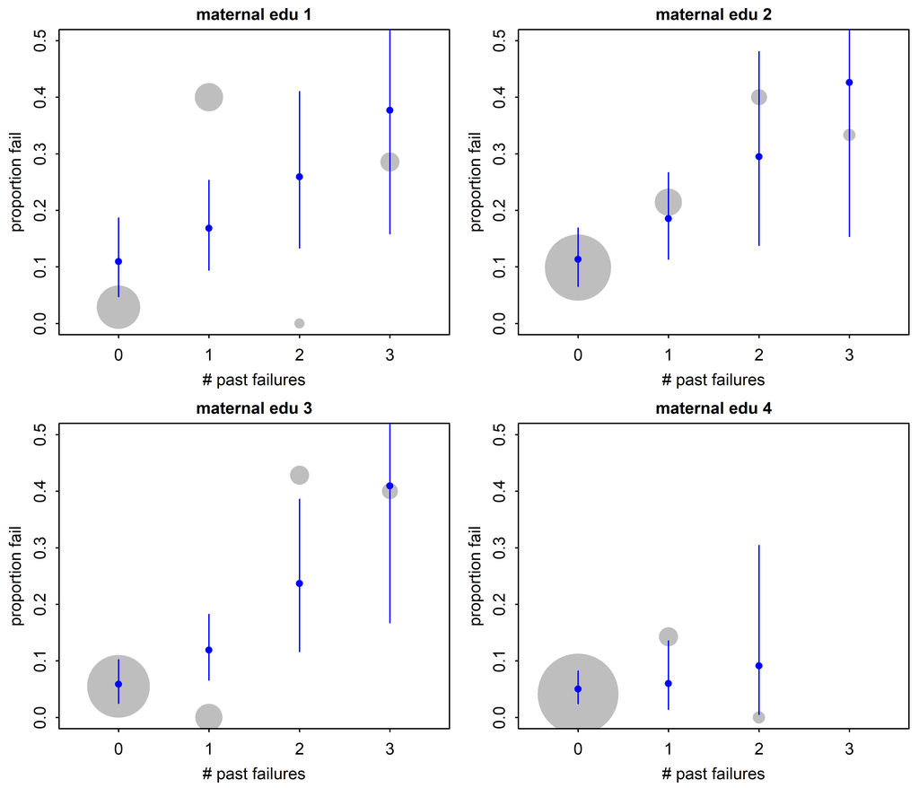

```r
sim.data =
  unique(as.data.frame(data.list)[,c(1,2)])

p = link_ulam(
  u.fit_FE.2,
  data = sim.data)

pp.stats = cbind(
  sim.data,
  m = colMeans(p),
  t(apply(p,2,PI))
)

set_par(mfrow = c(2,2), mar=c(3,3,1.5,0.5), cex = .75)
tmp =
  lapply(unique(obs$Medu), function(x) {
  plot(obs[obs$Medu == x,"failures"],
       obs[obs$Medu == x,"mean"],
       cex = sqrt(obs[obs$Medu == x,"N"]),
       xlim = c(-.5,3.5), ylim = c(0,.5),
       ylab = "proportion fail",
       xlab = "# past failures",
       xaxt = "n", pch = 16, col = "grey")
    title(paste("maternal edu",x),line = 0.5, cex.main = 1)
    axis(1,at = 0:3)
    points(pp.stats[pp.stats$Medu == x,"failures"],
       pp.stats[pp.stats$Medu == x,"m"], pch = 16, col = "blue")
    arrows(pp.stats[pp.stats$Medu == x,"failures"],
           y0 = pp.stats[pp.stats$Medu == x,"5%"],
           y1 = pp.stats[pp.stats$Medu == x,"94%"],
           length = 0, col = "blue")
})
```

This does not look that much better. Let’s check this with PSIS-LOO:

```r
compare(u.fit_FE.2,u.fit_FE, func = "PSIS")
```

```
##                PSIS       SE    dPSIS      dSE    pPSIS     weight
## u.fit_FE   232.8903 25.44469 0.000000       NA 2.983973 0.96927994
## u.fit_FE.2 239.7935 25.56751 6.903275 3.156645 7.044966 0.03072006
```

In this case the added complexity has not helped much. So lets look at the parameters of the first model:

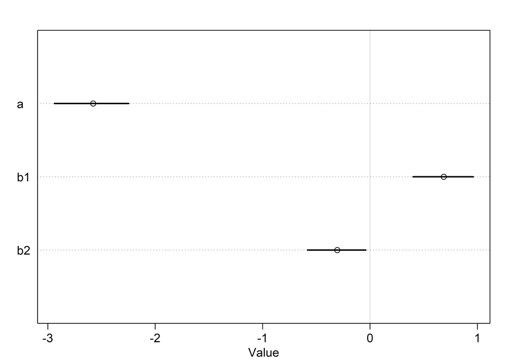

```r
plot(precis(u.fit_FE, depth = 2))
```

```r
precis(u.fit_FE, depth = 2) %>% round(2)
```

```
##     mean   sd  5.5% 94.5%   n_eff Rhat4
## a  -2.58 0.22 -2.94 -2.25 2403.70     1
## b1  0.69 0.18  0.40  0.96 2374.19     1
## b2 -0.31 0.17 -0.58 -0.04 2735.87     1
```

What does this all mean?

Because the parameters are log-odds ratios, we exponentiate them to get ORs. Because the probability of our outcome is (relatively) close to zero, we can interprete the OR as approximate risk ratios. Hence

- the intercept value is -2.58, which gives a baseline risk of 0.075774
- the regression weight for failures is 0.69, which means that the odds ratio and approximate relative risk to fail the class if one has failed it once before is exp(0.69) 1.99.
- the regression weight for maternal education is -0.31, which means that the odds ratio and approximate relative risk to fail the class if one has failed it once before is exp(-0.31) = 0.73. Correspondingly, if maternal education is changed by two levels, the OR (~RR) is exp(2 * -0.31) = 0.54

## Constrasts

The OR and relative risks that we have to deal with due to the link function make it hard to interpret the results. But if we create posterior predictions we can simply calculate contrasts.

Lets look at the data we used to generate posterior predictions:

```r
sim.data =
  unique(as.data.frame(u.fit_FE@data)[, c("cMedu","failures","Medu")])
sim.data = sim.data[order(sim.data$cMedu,sim.data$failures),]
rownames(sim.data) = NULL
sim.data
```

```
##    cMedu failures Medu
## 1   -1.5        0    1
## 2   -1.5        1    1
## 3   -1.5        2    1
## 4   -1.5        3    1
## 5   -0.5        0    2
## 6   -0.5        1    2
## 7   -0.5        2    2
## 8   -0.5        3    2
## 9    0.5        0    3
## 10   0.5        1    3
## 11   0.5        2    3
## 12   0.5        3    3
## 13   1.5        0    4
## 14   1.5        1    4
## 15   1.5        2    4
```

If we now generate the posterior predictions, we get a matrix in which each column corresponds to one row in `sim.data`

```r
pp = link_ulam(
  u.fit_FE,
  data = sim.data)
dim(pp)
```

```
## [1] 4000   15
```

A simple question would be what the effect of having one vs zero previous failures is when maternal educational level is 1. We simply look up in the `sim.data` table that we need to compare columns one and two in the posterior predictions for this. In the same manner we can do this for maternal educational level 2.

```r
# effect of prior failure for Medu = 1
delta.L1 = pp[,2] - pp[, 1]
# effect of prior failure for Medu = 2
delta.L2 = pp[,6] - pp[, 5]
```

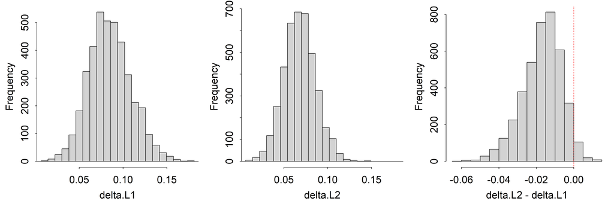

```r
# plot data
xlim = range(c(delta.L1,delta.L2))
breaks = seq(xlim[1]-.01,xlim[2]+.01, length.out = 25)
set_par(mfrow = c(1,3), cex = 1.5)
hist(delta.L1, main = "", xlim = xlim, breaks = breaks)
abline(v = 0, col = "red", lty = 3)
hist(delta.L2, main = "", xlim = xlim, breaks = breaks)
abline(v = 0, col = "red", lty = 3)
hist(delta.L2-delta.L1, main = "")
abline(v = 0, col = "red", lty = 3)
```

> This interaction effect can also be understood by remembering that odds ratios are relative effects, i.e. the effect of a one unit change of a variable depends on the probability of success at the comparison value. Here is an example with numbers. Lets assume our intercepts for two groups are 1 and 2, respecitively, and the log-odds ration for the effect of interest is 1. Then we can calculate the risk differences as `inv_logit(1+1) - inv_logit(1+0)` = 0.15 and `inv_logit(2+1) - inv_logit(2+0)` = 0.07, and see that the absolute effect of the logg odds ratio depends on the starting point. Calculate `inv_logit(1+1) / inv_logit(1+0)` and `inv_logit(2+1) / inv_logit(2+0)` and compare the results. Therefore, the meaningfulness of a result in log odds ratio can only be understood based on some background knnowledge.

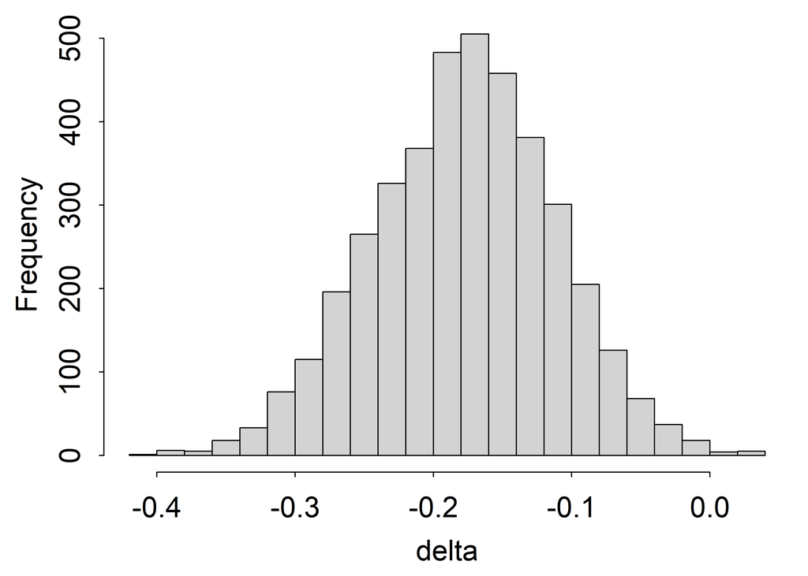

```r
fail.level1 = rowMeans(pp[,1:4])
fail.level4 = rowMeans(pp[,13:15])
delta = fail.level4 - fail.level1
set_par( mar=c(3,3,.5,.5), cex = 1.5)
hist(delta, breaks = 25, main = "")
```

However, this analysis assumed that the pupils with different number of previously failed classes are equally frequent, which is not the case. So we need to weight with these probabilities:

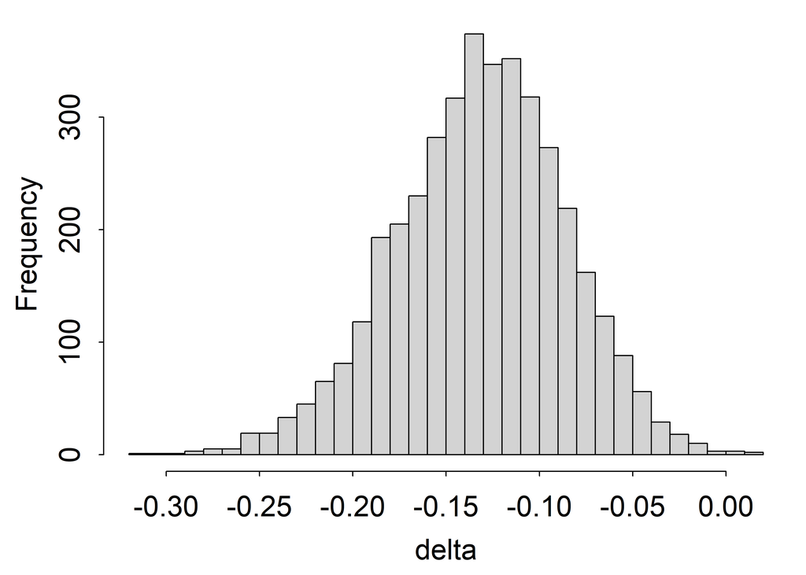

```r
M1_p.failures = prop.table(table(df$failures[df$Medu == 1]))
M4_p.failures = prop.table(table(df$failures[df$Medu == 4]))
fail.level1 = pp[,1:4] %*% M1_p.failures
fail.level4 = pp[,13:15] %*% M4_p.failures
delta = fail.level4 - fail.level1
set_par( mar=c(3,3,.5,.5), cex = 1.5)
hist(delta, breaks = 25, main = "")
```

This are just two examples. Every calculation we can make based on the posterior prediction is legal!

# Aggregated binomial regression

The binomial regression is the general case of which the logistic regression is a special case. Both have a logistic link function, but whereas logistic regressions estimates if one trial was a “success”, binomial regressions estimate how many out of N trials were successes.

To look at the aggregated binomial regression we will look at data from Norwegian tests and ask the questions “Does the number of excused children depend on the topic English, reading or Math?”

Here is the data:

[output not shown]

[output cut: 362 more lines]

```r
load(file = "data/NasjonalTests5.Rdata")

NatTests5 %>%
  kable() %>%
  kable_styling(full_width = FALSE)
```

| Fylke | topic | N_total | N_part | N_Miss | N_Exc | Fylke_Nr | topic_Nr |
| --- | --- | --- | --- | --- | --- | --- | --- |
| Viken | Eng | 15426 | 14399 | 209 | 818 | 1 | 1 |
| Viken | Math | 15426 | 14463 | 207 | 756 | 1 | 2 |
| Viken | Read | 15426 | 14392 | 155 | 879 | 1 | 3 |
| Vestland | Eng | 7684 | 7128 | 103 | 453 | 2 | 1 |
| Vestland | Math | 7684 | 7212 | 88 | 384 | 2 | 2 |
| Vestland | Read | 7684 | 7115 | 108 | 461 | 2 | 3 |
| Oslo | Eng | 6978 | 6455 | 153 | 370 | 3 | 1 |
| Oslo | Math | 6978 | 6399 | 153 | 426 | 3 | 2 |
| Oslo | Read | 6978 | 6406 | 125 | 447 | 3 | 3 |
| Rogaland | Eng | 6451 | 6038 | 78 | 335 | 4 | 1 |
| Rogaland | Math | 6451 | 6048 | 74 | 329 | 4 | 2 |
| Rogaland | Read | 6451 | 5971 | 80 | 400 | 4 | 3 |
| Trøndelag | Eng | 5464 | 5000 | 109 | 355 | 5 | 1 |
| Trøndelag | Math | 5464 | 5030 | 117 | 317 | 5 | 2 |
| Trøndelag | Read | 5464 | 5004 | 110 | 350 | 5 | 3 |
| Vestfold og Telemark | Eng | 4863 | 4484 | 58 | 321 | 6 | 1 |
| Vestfold og Telemark | Math | 4863 | 4543 | 53 | 267 | 6 | 2 |
| Vestfold og Telemark | Read | 4863 | 4483 | 54 | 326 | 6 | 3 |
| Agder | Eng | 3911 | 3621 | 63 | 227 | 7 | 1 |
| Agder | Math | 3911 | 3650 | 62 | 199 | 7 | 2 |
| Agder | Read | 3911 | 3618 | 54 | 239 | 7 | 3 |
| Innlandet | Eng | 3804 | 3497 | 75 | 232 | 8 | 1 |
| Innlandet | Math | 3804 | 3526 | 65 | 213 | 8 | 2 |
| Innlandet | Read | 3804 | 3502 | 81 | 221 | 8 | 3 |
| Møre og Romsdal | Eng | 3185 | 2908 | 25 | 252 | 9 | 1 |
| Møre og Romsdal | Math | 3185 | 2934 | 28 | 223 | 9 | 2 |
| Møre og Romsdal | Read | 3185 | 2865 | 33 | 287 | 9 | 3 |
| Nordland | Eng | 2645 | 2394 | 74 | 177 | 10 | 1 |
| Nordland | Math | 2645 | 2420 | 74 | 151 | 10 | 2 |
| Nordland | Read | 2645 | 2375 | 85 | 185 | 10 | 3 |
| Troms og Finnmark | Eng | 2607 | 2364 | 58 | 185 | 11 | 1 |
| Troms og Finnmark | Math | 2607 | 2380 | 60 | 167 | 11 | 2 |
| Troms og Finnmark | Read | 2607 | 2297 | 112 | 198 | 11 | 3 |

To set up a binomial model, we set up a model that

- allows the number of trials (total number of students) vary from observation to observation.
- allows different intercepts for different Fylke, using the indexing approach
- estimates a global effect of topic across all Fylke, using the indexing approach.

Here is the model:

```r
NT.model =
  alist(
    N_Exc ~ dbinom(N_total, p),
    logit(p) <- a[Fylke_Nr] + b[topic_Nr],
    a[Fylke_Nr] ~ dnorm(0,1),
    b[topic_Nr] ~ dnorm(0,1))
```

Here we are fitting the model.

```r
u.fit_NT = ulam(
  NT.model,
  data = NatTests5,
  log_lik = TRUE,   # for model comparison
  iter = 2000,      # 2000 iterations, (1000 warmup)
  chains = 4,       # four chains, to check convergence
  cores = 4,        # use 4 cores in parallel
  cmdstan = TRUE)   # use cmdstanr not rstan
```

[output not shown]

[output not shown]

[output not shown]

[output not shown]

[output not shown]

[output not shown]

[output not shown]

[output not shown]

[output not shown]

[output not shown]

[output not shown]

[output not shown]

[output not shown]

[output not shown]

[output not shown]

[output not shown]

[output not shown]

[output not shown]

[output not shown]

[output not shown]

[output not shown]

[output not shown]

[output not shown]

[output not shown]

[output not shown]

[output not shown]

[output not shown]

[output not shown]

[output not shown]

[output not shown]

[output not shown]

[output cut: 43 more lines]

[output not shown]

```r
precis(u.fit_NT, depth = 2) %>% round(2)
```

```
##        mean   sd  5.5% 94.5%  n_eff Rhat4
## a[1]  -0.76 0.25 -1.19 -0.36 161.56  1.03
## a[2]  -0.70 0.25 -1.13 -0.30 162.46  1.03
## a[3]  -0.64 0.25 -1.08 -0.24 162.38  1.03
## a[4]  -0.72 0.25 -1.16 -0.32 161.97  1.03
## a[5]  -0.59 0.25 -1.01 -0.19 163.54  1.03
## a[6]  -0.59 0.25 -1.02 -0.18 163.41  1.03
## a[7]  -0.69 0.26 -1.12 -0.29 163.40  1.03
## a[8]  -0.66 0.25 -1.09 -0.26 166.14  1.03
## a[9]  -0.33 0.25 -0.76  0.08 163.12  1.03
## a[10] -0.55 0.25 -0.98 -0.15 160.93  1.03
## a[11] -0.46 0.26 -0.88 -0.05 166.86  1.03
## b[1]  -2.12 0.25 -2.52 -1.68 161.41  1.03
## b[2]  -2.20 0.25 -2.61 -1.78 161.44  1.03
## b[3]  -2.04 0.25 -2.45 -1.61 161.02  1.03
```

n_eff and Rhat don’t look great. We look at traceplot for the first a and b to figure out what is going on:

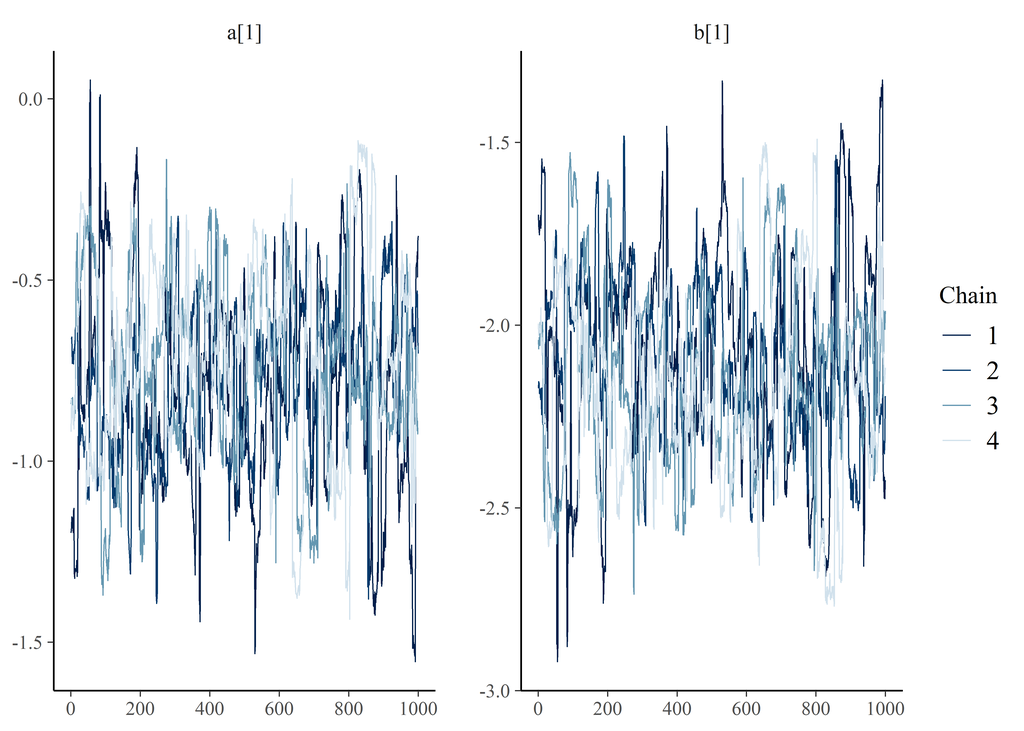

```r
library(posterior)
library(bayesplot)
draws = u.fit_NT@stanfit %>% as_draws()
draws %>% subset_draws(c("a[1]","b[1]")) %>% mcmc_trace()
```

The chains are not mixed as well as one would hope, and it looks a bit like the chains are correlated. WE examine this with a pairs plot:

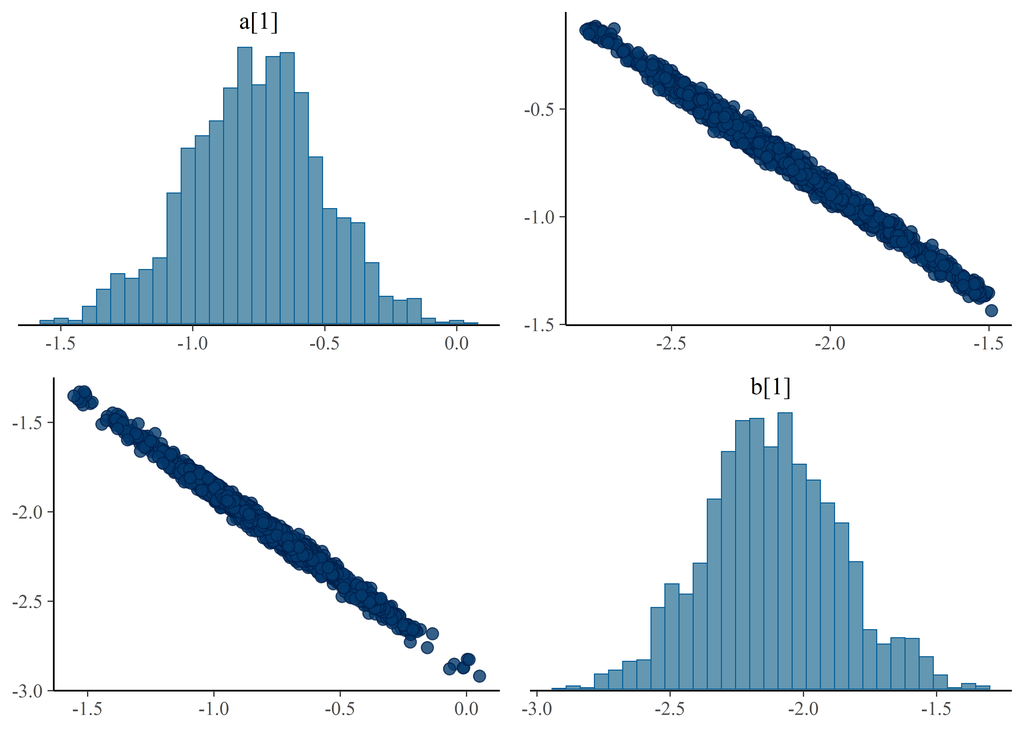

```r
draws %>% subset_draws(c("a[1]","b[1]")) %>% mcmc_pairs()
```

The strong negative correlation reminds us that the Fylke intercept actually already represents the proportion of excused pupils in the first (any one of the) topics. WE have to re-formulate the model and use only two of the topics.

We update our data:

```r
NatTests5$Math = 1*(NatTests5$topic == "Math")
NatTests5$Eng = 1*(NatTests5$topic == "Eng")
```

And we formulate and estimate an updated model:

```r
NT.model2 =
  alist(
    N_Exc ~ dbinom(N_total, p),
    logit(p) <- a[Fylke_Nr] + b1*Math + b2*Eng,
    a[Fylke_Nr] ~ dnorm(0,1),
    b1 ~ dnorm(0,1),
    b2 ~ dnorm(0,1))

u.fit_NT2 = ulam(
  NT.model2,
  data = NatTests5,
  log_lik = TRUE,   # for model comparison
  iter = 2000,      # 2000 iterations, (1000 warmup)
  chains = 4,       # four chains, to check convergence
  cores = 4,        # use 4 cores in parallel
  cmdstan = TRUE)   # use cmdstanr not rstan
```

[output not shown]

[output not shown]

[output not shown]

[output not shown]

[output not shown]

[output not shown]

[output not shown]

[output not shown]

[output not shown]

[output not shown]

[output not shown]

[output not shown]

[output not shown]

[output not shown]

[output not shown]

[output not shown]

[output not shown]

[output not shown]

[output not shown]

[output not shown]

[output not shown]

[output not shown]

[output not shown]

[output not shown]

[output not shown]

[output not shown]

[output not shown]

[output not shown]

[output not shown]

[output not shown]

[output not shown]

[output not shown]

[output not shown]

[output not shown]

[output not shown]

[output not shown]

[output not shown]

[output not shown]

[output not shown]

[output cut: 43 more lines]

[output not shown]

```r
precis(u.fit_NT2, depth = 2) %>% round(2)
```

```
##        mean   sd  5.5% 94.5%   n_eff Rhat4
## a[1]  -2.80 0.02 -2.84 -2.76 2348.52     1
## a[2]  -2.74 0.03 -2.79 -2.68 3344.66     1
## a[3]  -2.68 0.03 -2.73 -2.63 3454.29     1
## a[4]  -2.76 0.03 -2.82 -2.70 3264.06     1
## a[5]  -2.63 0.03 -2.68 -2.57 3119.15     1
## a[6]  -2.62 0.04 -2.68 -2.56 3428.74     1
## a[7]  -2.73 0.04 -2.79 -2.66 3005.10     1
## a[8]  -2.70 0.04 -2.76 -2.63 3993.71     1
## a[9]  -2.36 0.04 -2.43 -2.30 3925.30     1
## a[10] -2.59 0.05 -2.66 -2.51 3418.92     1
## a[11] -2.50 0.05 -2.57 -2.42 4127.12     1
## b1    -0.17 0.02 -0.21 -0.13 1880.89     1
## b2    -0.08 0.02 -0.12 -0.04 1861.85     1
```

This looks much better.

Here is a posterior predictive plot.

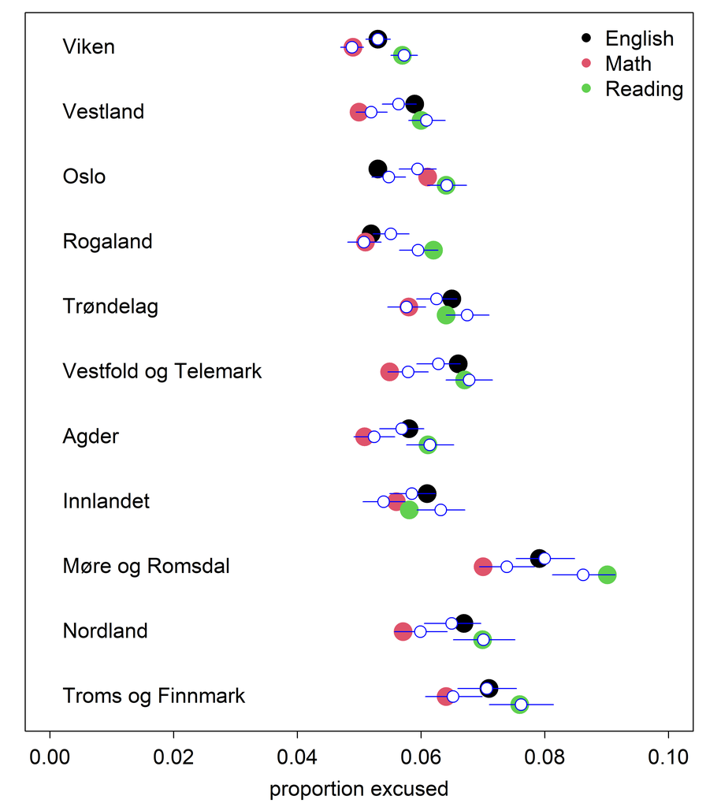

```r
NatTests5$obs = NatTests5$N_Exc/NatTests5$N_total
NatTests5$x = NatTests5$Fylke_Nr + (NatTests5$topic_Nr-2)/8

set_par(mar=c(3,1,.5,.5))

with(NatTests5,
     plot(obs, rev(x), cex = 2, col = topic_Nr,
          pch = 16, xlim = c(0,.1),
          yaxt = "n", ylab = "", xlab = "proportion excused")
     )

with(NatTests5[NatTests5$topic == "Math",],
     text(0, rev(x), Fylke, pos = 4)
     )

legend("topright", col = 1:3,
       legend = c("English","Math","Reading"), bty = "n", pch = 16)

pp = link(u.fit_NT2)
CI = apply(pp,2,PI)
arrows(y0 = rev(NatTests5$x), x0 = CI[1,], x1 = CI[2,], col = "blue", length = 0)
points(colMeans(pp), rev(NatTests5$x), cex = 1.25,
       col = "blue", pch = 21, bg = "white")
```

What do the coefficients tell us?

- the intercepts vary between -2.36 for Møre og Romsdal, i.e. the probability to be excused from the reading test is `exp(-2.36)` = 0.09, and -2.8 for Viken, i.e. the probability to be excused from the reading test is `exp(-2.8)` = 0.06. This means that the chance to be excused from the reading test is `exp(-2.36)/exp(-2.8) = 1.55 larger in Møre og Romsdal, compared to Viken.

Here is a plot with the log odds to be excused from the reading test by Fylke:

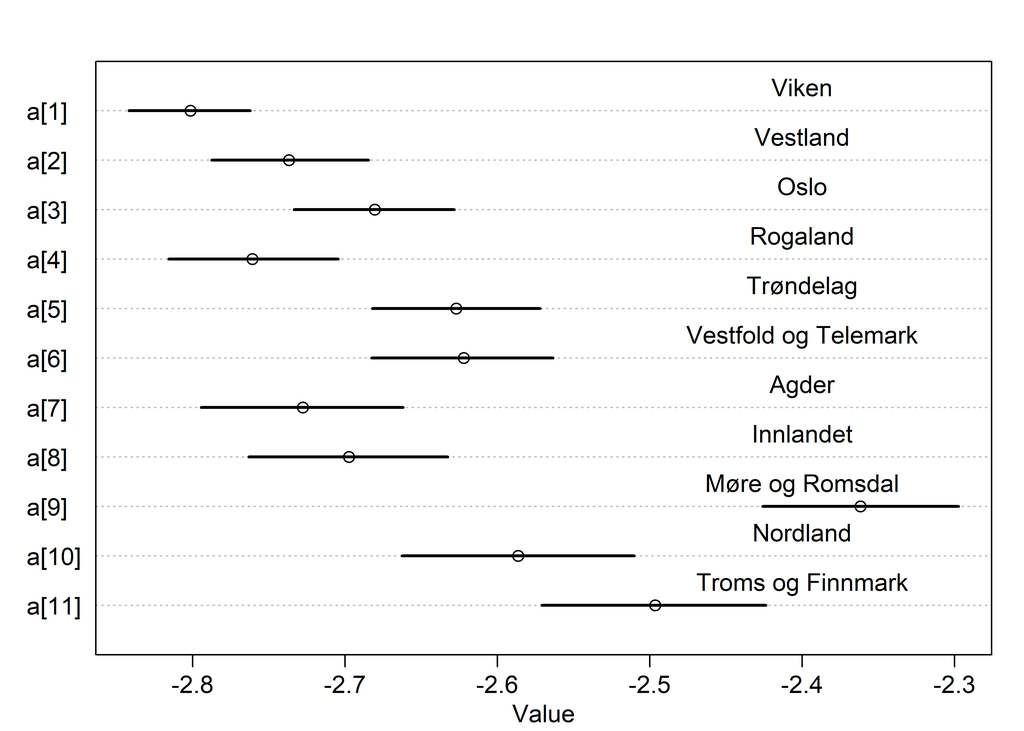

```r
plot(precis(u.fit_NT2, depth = 2, pars = "a"))
yy = unique(NatTests5[,c("Fylke","Fylke_Nr")])
text(-2.4,rev(yy$Fylke_Nr), yy$Fylke,pos = 3)
```

Regarding the effect of topic we find that

- the log odds ratio for math is -.17, i.e. the odds ratio is `exp(-.17)` = 0.84. Because the baseline probability for reading is low, we can simply say that the relative risk to be excused from the math test is 0.84
- the log odds ratio for English is -.08, i.e. the odds ratio is `exp(-.08)` = 0.92. Because the baseline probability for reading is low, we can simply say that the relative risk to be excused from the math test is 0.92
[^1]: P. Cortez and A. Silva. Using Data Mining to Predict Secondary School Student Performance. In A. Brito and J. Teixeira Eds., Proceedings of 5th FUture BUsiness TEChnology Conference (FUBUTEC 2008) pp. 5-12, Porto, Portugal, April, 2008, EUROSIS, ISBN 978-9077381-39-7. Data can be downloaded [here](https://archive.ics.uci.edu/ml/datasets/Student+Performance)
[^2]: There are also distributions with 1 or 3 or more parameters
[^3]: I plugged this number from thin air, should really to a quick calculation on this.